# TrackeR

David F. Severski (@dseverski)

August 27, 2016

# Data Import

```r
today <- readTCX(file = "./data/garmin/activity_1323723072.tcx")
yesterday <- readTCX(file = "./data/garmin/activity_1245499673.tcx")
```

Garmin Connect TCX exports are easy to read and include:

- lat/long
- alt
- distance
- heart.rate

RunKeeper exports are in GPX format, which are XML files. These are `trkseg` elements, with child collections of `trkpt` elements. Track points are recorded for each auto-waypoint (time based) by the RunKeeper iOS app and have attriutes of:

- lat
- long

And child items of:

- ele (elevation)
- time (UTC)

```r
runk <- xml2::read_xml(file("./data/runkeeper/2016-08-27-0910.gpx"))
ns <- xml_ns(runk)
times <- xml_find_all(runk, ".//d1:time", ns = ns) %>% xml_text %>% ymd_hms %>%
  as_data_frame %>% mutate(interval = value - lag(value))
foo <- xml_find_first(runk, ".//d1:trkpt", ns = ns) %>% xml_attrs()
```

There’s also the `cycleRtools` package on CRAN.

While I’d like to be able to download all my Garmin activities at once, the Connect platform actively discourages users from this (API access is $5k!), with the only easy solution being a web app that wants your credentials in order to impersonate you. 😞:(

For now, manually copying all the files saved via the Garmin ANT agent to `data/garmin`. This means that elevation information is the raw altitude information from the watch. On the Garmin 410 that I use, that’s fairly inaccurate (both Garmin Connect and RunKeeper do cross checks of lat/longs with third party topographic services in order to provide better data).

```r
url <- "https://connect.garmin.com/en-US/signin"
pgsession <- html_session(url)
```

Load in all of the TCX files. Convert the time to duration for consistent cross-run plots.

```r
if(file.exists("./data/runs.rds")) {
   runs <- readRDS("./data/runs.rds")
} else {
  runs <- NULL
}
read_data <- function(x) {
  message(paste0("Reading file: ", x))
  dat <- readTCX(file = x)
  dat$duration <- as.integer(dat$time - dat[1, "time"])
  dat$name <- basename(x)
  return(dat)
}
files_to_load <- setdiff(dir("./data/garmin", "*.TCX", full.names = FALSE),
                         runs$name)
if(length(files_to_load > 0)) {
  files_to_load <- paste0("./data/garmin/", files_to_load)
  runs <- bind_rows(runs, map_df(files_to_load, read_data))
  saveRDS(runs, "./data/runs.rds")
  message("New files added:\n", paste0("\t", files_to_load, collapse="\n"))
} else {
  message("No new files to load.")
}
```

```
No new files to load.
```

To get a trackeRdata object, we need to drop our computed columns. Once made into a `trackeRdata` type, the `summary` and `plot` methods have useful defaults.

Note: All variables are all converted from metric to imperial units becuase I’m a dumb American and thinking in terms of m/sec is hard.

```r
runs_trackr <- select(runs, -duration, -name) %>%
  trackeRdata(data.frame(variable = c("latitude", "longitude",  "altitude",
                                      "distance", "heart.rate", "speed",
                                      "cadence", "power"),
                         unit = c("degree", "degree", "m",
                                  "m", "bpm",  "m_per_s",
                                  "steps_per_min", "W"))) %>%
  changeUnits(., variable = c("altitude", "speed", "distance", "pace"),
              unit = c("ft", "mi_per_h", "mi", "min_per_mi"))
```

```
Observations with duplicated time stamps are removed.
```

```r
runsT <- threshold(runs_trackr, "heart.rate", 0, 200)
summary(runsT, session = length(runsT))
```

```
 *** Session 83 ***

 Session times: 2016-11-27 07:29:48 - 2016-11-27 09:12:26
 Distance: 13.27 mi
 Duration: 1.71 hours
 Moving time: 1.62 hours
 Average speed: 7.76 mi_per_h
 Average speed moving: 8.18 mi_per_h
 Average pace (per 1 mi): 7:44 min:sec
 Average pace moving (per 1 mi): 7:20 min:sec
 Average cadence: NA steps_per_min
 Average cadence moving: NA steps_per_min
 Average power: NA W
 Average power moving: NA W
 Average heart rate: 159.56 bpm
 Average heart rate moving: 159.9 bpm
 Average heart rate resting: 151.18 bpm
 Work to rest ratio: 18.18

 Moving threshold: 2.24 mi_per_h
```

## Data Validation

The trackeR package does not return the activity type encoded in the TCX file, though there is logic for treating cycling and running sessions differently in the other processing sections. Some manual checking of the files in the data directory versus what is aggregated follows.

```r
mutate(runs, start = as.Date(time)) %>% select(start) %>% unique -> file_dates
map_df(runs_trackr, ~ data_frame(start = range(index(.))[1],
                                 stop = range(index(.))[2]), .id = NULL) %>%
  mutate(start = as.Date(start)) %>% select(start) -> agg_dates
agg_dates$start %in% file_dates$start
```

```
 [1] TRUE TRUE TRUE TRUE TRUE TRUE TRUE TRUE TRUE TRUE TRUE TRUE TRUE TRUE TRUE TRUE TRUE TRUE TRUE TRUE
[21] TRUE TRUE TRUE TRUE TRUE TRUE TRUE TRUE TRUE TRUE TRUE TRUE TRUE TRUE TRUE TRUE TRUE TRUE TRUE TRUE
[41] TRUE TRUE TRUE TRUE TRUE TRUE TRUE TRUE TRUE TRUE TRUE TRUE TRUE TRUE TRUE TRUE TRUE TRUE TRUE TRUE
[61] TRUE TRUE TRUE TRUE TRUE TRUE TRUE TRUE TRUE TRUE TRUE TRUE TRUE TRUE TRUE TRUE TRUE TRUE TRUE TRUE
[81] TRUE TRUE TRUE
```

# Overview

Summary of all sessions.

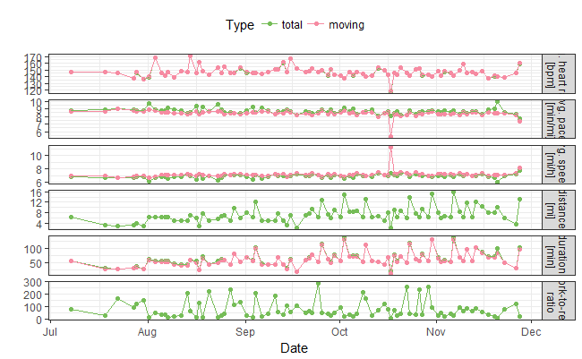

A timeline of all sessions and their duration is available via the `timeline` function.

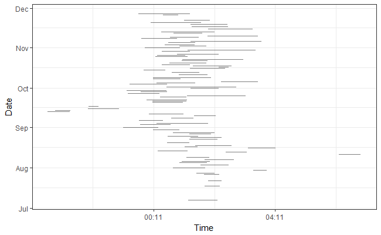

## Weekly Averages

```r
run_lengths <- as_data_frame(summary(runsT)) %>%
  group_by(week = week(as.Date(sessionEnd))) %>%
  summarize(distance = sum(distance),
            duration = as.numeric(sum(duration), units = "hours"))
run_lengths
```

| week | distance | duration |
| --- | --- | --- |
| 27 | 6.532272 | 0.9500000 |
| 29 | 3.264949 | 0.4852778 |
| 30 | 10.480650 | 1.5530556 |
| 31 | 15.817276 | 2.4275000 |
| 32 | 28.856729 | 4.2700000 |
| 33 | 28.643362 | 4.2205556 |
| 34 | 24.776970 | 3.6788889 |
| 35 | 29.013379 | 4.1283333 |
| 36 | 28.694738 | 4.2319444 |
| 37 | 28.483919 | 4.0988889 |

[output cut: 11 more lines]

# Training Zones

Heart rate training zones from [active](http://www.active.com/fitness/articles/how-to-calculate-your-training-heart-rate-zones)

```r
get_zones <- function(age = 43, resting_hr = 47) {
  hr_max <- 208 - .7 * age     # ref Tanaka (2001)
  reserve_hr <- hr_max - resting_hr
  fatburn <- c(low = .5 * reserve_hr, high = .75 * reserve_hr)
  fatburn_zone = fatburn + resting_hr
  aerobic <- c(low = .75 * reserve_hr, high = .85 * reserve_hr)
  aerobic_zone = aerobic + resting_hr
  anaerobic <- c(low = .85 * reserve_hr, high = .95 * reserve_hr)
  anaerobic_zone = anaerobic + resting_hr
  return(data.frame(hr_max = hr_max, resting = resting_hr,
                    fat_low = fatburn_zone[[1]],
                    fat_high = fatburn_zone[[2]],
                    aerobic_low = aerobic_zone[[1]],
                    aerobic_high = aerobic_zone[[2]],
                    anaerobic_low = anaerobic_zone[[1]],
                    anaerobic_high = anaerobic_zone[[2]]))
}
hr_zones <- get_zones(age = 43, resting_hr = 45)
hr_zones
```

| hr_max | resting | fat_low | fat_high | aerobic_low | aerobic_high | anaerobic_low | anaerobic_high |
| --- | --- | --- | --- | --- | --- | --- | --- |
| 177.9 | 45 | 111.45 | 144.675 | 144.675 | 157.965 | 157.965 | 171.255 |

Let’s look at our range of raw heart rates

```r
raw_hr <- map(runs_trackr, ~ .x$"heart.rate") %>% map(., coredata) %>% unlist
summary(raw_hr)
```

```
   Min. 1st Qu.  Median    Mean 3rd Qu.    Max.    NA's
   42.0   138.0   143.0   146.6   152.0   250.0    2966
```

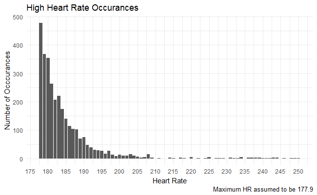

```r
high_hr <- raw_hr[!is.na(raw_hr) & raw_hr > hr_zones$hr_max] %>% sort %>%  rle %>%
  unclass %>% as_data_frame %>% arrange(values)
break_points <- c("low" = hr_zones$hr_max - (hr_zones$hr_max %% 5),
                  "high" = max(high_hr$values) + (max(high_hr$values) %% 5))
ggplot(high_hr, aes(x = values, y = lengths)) +
  geom_col() +
  theme_minimal() +
  labs(title = "High Heart Rate Occurances", x = "Heart Rate",
       y = "Number of Occcurances",
       caption = paste("Maximum HR assumed to be", hr_zones$hr_max)) +
  scale_x_continuous(breaks = seq(from = break_points["low"],
                                  to = break_points["high"], by = 5))
```

trackeR can compute the amount of time in various `heart.rate` and `speed` zones. The default plot is a bit ungraceful, but it is ggplot and the data is returned in a clean list for additional processing if desired.

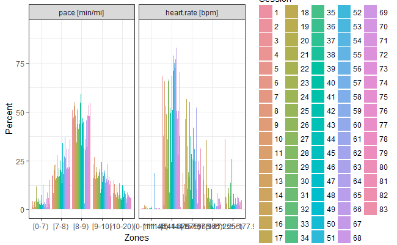

```r
dat <- zones(runs_trackr, breaks = list(pace = c(0, 7, 8, 9, 10, 20),
                                heart.rate = c(0, hr_zones$fat_low,
                                               hr_zones$aerobic_low,
                                               hr_zones$anaerobic_low,
                                               hr_zones$anaerobic_high,
                                               hr_zones$hr_max)))
plot(dat)
```

We can do some overrides on the default plot output to show the same plot, summarized across all sessions.

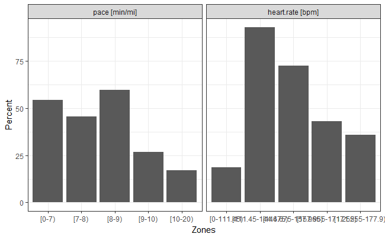

```r
new_aes <- aes(x = zoneF, y = percent)
gg <- plot(dat)
gg$layers[[1]]$mapping <- ggplot2:::rename_aes(new_aes)
gg
```

```r
rm(new_aes, gg)
```

Of course, we can also do this ourselves with a bit of ggplot.

```r
zone_colors <- viridis_pal()(3)
dat <- runs
gg <- ggplot(dat, aes(x = duration, y = heart.rate))
gg <- gg + geom_ribbon(aes(xmin = min(dat$duration), xmax = max(dat$duration),
                           ymin = hr_zones$fat_low, ymax = hr_zones$fat_high),
                       alpha = 0.5, fill = zone_colors[1])
gg <- gg + geom_ribbon(aes(xmin = min(runs$duration), xmax = max(runs$duration),
                           ymin = hr_zones$aerobic_low, ymax = hr_zones$aerobic_high),
                       alpha = 0.5, fill = zone_colors[2])
gg <- gg + geom_line(aes(group = name), alpha = 0.7) + geom_smooth()
gg <- gg + scale_x_continuous(labels = comma)
gg <- gg + theme_minimal()
gg <- gg + labs(title = "Heart Rate Over Time")
gg <- gg + labs(caption = "Garmin Connect TCX data")
gg <- gg + labs(subtitle = "How often are we in \"The Zone\"?")
gg <- gg + labs(x = "Duration (seconds)")
gg <- gg + labs(y = "Heart rate (bpm)")
gg
```

[output not shown]

# Single Run Plots

Pace and heart rate charts for the most recent run.

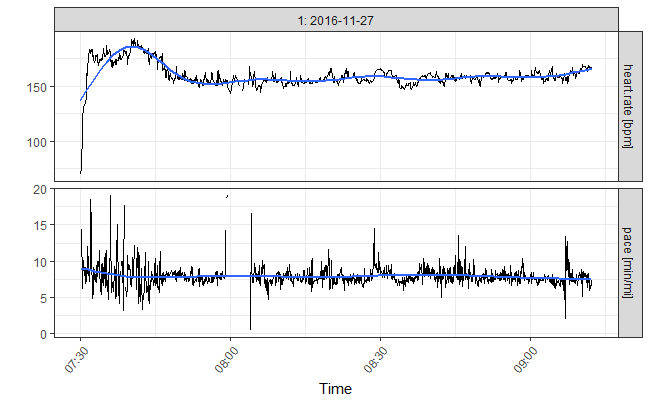

```r
recent_run <- length(runsT)
plot(runsT[recent_run])
```

```r
plotRoute(runsT, session = recent_run, maptype = "roadmap")
```

[output not shown]

We can also create interactive maps.

```r
leafletRoute(runsT, session = (recent_run - 4):recent_run)
```

[output not shown]

# Distribution Profiles

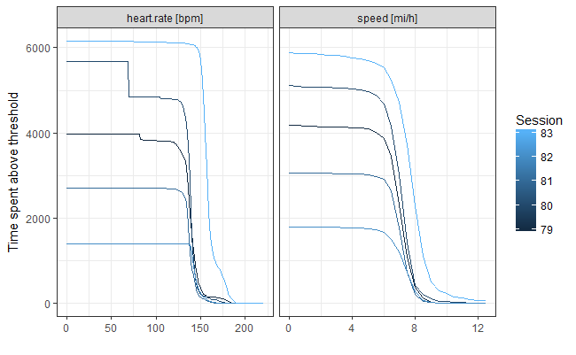

```r
d_profile <- distributionProfile(runsT,
                                 session = (length(runsT) - 4):length(runsT),
                                 what = c("speed", "heart.rate"),
                                 grid = list(
                                   speed = seq(0, 12.5, by = 0.5),
                                   heart.rate = seq(0, 220)))
plot(d_profile, multiple = TRUE, smooth = FALSE)
```

# Concentration Profiles

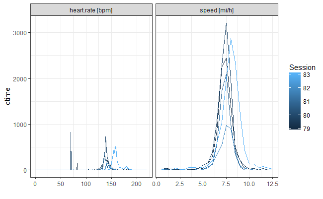

```r
c_profile <- concentrationProfile(d_profile, what = c("speed", "heart.rate"))
plot(c_profile, smooth = FALSE, multiple = TRUE)
```